# Results

Shadi

2023-06-20

## Descriptive Analysis

### Table 1: Baseline Characteristics for states

Baseline Comparison of States

| Group | Variable | Non Expansion | Expansion | Difference |
| --- | --- | --- | --- | --- |
| Pre-ACA | State’s Political Liberalism | 0.45 (0.17) | 0.24 (0.09) | 0.22*** |
|  | Immigration Policy Climate | -1 (2) | -3 (1) | 2.1*** |
|  | State’s Unemployment Rate | 8.60 (1.64) | 7.16 (2.02) | 1.4*** |
| Post-ACA | State’s Political Liberalism | 0.47 (0.22) | 0.23 (0.10) | 0.24*** |
|  | Immigration Policy Climate | 0 (3) | -3 (1) | 2.8*** |
|  | State’s Unemployment Rate | 5.00 (1.14) | 4.50 (1.15) | 0.50*** |

<sup>1</sup> Mean (SD)  
<sup>2</sup> *p<0.05; **p<0.01;*** p<0.001

### Table 2: Baseline Characteristics by Nativity

Table 2 provides a comprehensive summary of the demographic characteristics, insurance rates, and Medicaid coverage of the low-income adult sample prior to the implementation of the Affordable Care Act. It includes the pre-expansion means for age and proportions of various variables, specifically distinguishing between foreign-born and US-born individuals in states that expanded their Medicaid later and non-expansion states that did not expand their Medicaid until 2019.

Significant differences were observed across all demographic characteristics between foreign-born and US-born adults. However, while substantial disparities were found between native and foreign-born individuals in both expansion and non-expansion states, the discrepancies between native-born individuals in expansion and non-expansion states were relatively smaller in magnitude. The same trend was observed for foreign-born individuals.

Baseline Characteristics by Nativity

| Characteristic | expansion Foregin-born, 11592215 | expansion US-born, 34946509 | expansion p-value | Non-expansion Foregin-born, 7113051 | Non-expansion US-born, 26041282 | Non-expansion p-value |
| --- | --- | --- | --- | --- | --- | --- |
| Uninsured | 6,473,288 (56%) | 11,893,979 (34%) | <0.001*** | 4,995,253 (70%) | 10,833,686 (42%) | <0.001*** |
| Medicaid coverage | 2,880,034 (25%) | 13,241,734 (38%) | <0.001*** | 871,138 (12%) | 7,688,863 (30%) | <0.001*** |
| Age | 41 (34, 50) | 43 (33, 53) | <0.001*** | 40 (33, 49) | 43 (33, 53) | <0.001*** |
| Sex |  |  | <0.001*** |  |  | <0.001*** |
| Female | 6,323,790 (55%) | 19,813,110 (57%) |  | 3,819,350 (54%) | 15,057,504 (58%) |  |
| Male | 5,268,425 (45%) | 15,133,399 (43%) |  | 3,293,701 (46%) | 10,983,778 (42%) |  |
| Disability | 1,136,618 (9.8%) | 9,432,288 (27%) | <0.001*** | 663,792 (9.3%) | 7,060,627 (27%) | <0.001*** |
| Current employment status |  |  | <0.001*** |  |  | <0.001*** |
| Employed | 6,188,727 (53%) | 13,125,180 (38%) |  | 4,037,034 (57%) | 10,335,124 (40%) |  |
| Not in labor force | 4,083,199 (35%) | 16,444,592 (47%) |  | 2,376,172 (33%) | 11,975,810 (46%) |  |
| Unemployed | 1,320,289 (11%) | 5,376,737 (15%) |  | 699,845 (9.8%) | 3,730,348 (14%) |  |
| Marital status | 6,457,264 (56%) | 9,635,900 (28%) | <0.001*** | 4,094,355 (58%) | 8,063,391 (31%) | <0.001*** |
| Education |  |  | <0.001*** |  |  | <0.001*** |
| College degree | 797,858 (6.9%) | 2,860,619 (8.2%) |  | 470,230 (6.6%) | 1,884,546 (7.2%) |  |
| Graduate and beyond | 319,853 (2.8%) | 994,271 (2.8%) |  | 172,679 (2.4%) | 577,787 (2.2%) |  |
| High school | 2,822,810 (24%) | 12,647,283 (36%) |  | 1,833,018 (26%) | 9,500,208 (36%) |  |
| Less than high school | 5,866,533 (51%) | 6,839,940 (20%) |  | 3,557,536 (50%) | 5,819,385 (22%) |  |
| Some college or Associate degree | 1,785,161 (15%) | 11,604,396 (33%) |  | 1,079,588 (15%) | 8,259,356 (32%) |  |
| Race/ethnicity |  |  | <0.001*** |  |  | <0.001*** |
| Asian | 1,704,788 (15%) | 264,742 (0.8%) |  | 518,213 (7.3%) | 54,950 (0.2%) |  |
| Black | 501,427 (4.3%) | 6,817,804 (20%) |  | 563,959 (7.9%) | 7,362,213 (28%) |  |
| Hispanic | 7,914,764 (68%) | 3,998,364 (11%) |  | 5,382,119 (76%) | 2,731,265 (10%) |  |
| Other | 207,897 (1.8%) | 1,512,924 (4.3%) |  | 106,083 (1.5%) | 838,658 (3.2%) |  |
| White | 1,263,339 (11%) | 22,352,675 (64%) |  | 542,677 (7.6%) | 15,054,196 (58%) |  |
| Federal poverty |  |  | <0.001*** |  |  | <0.001*** |
| Income 100 to 138% poverty | 4,257,006 (37%) | 10,820,459 (31%) |  | 2,563,949 (36%) | 8,447,926 (32%) |  |
| Income below 100% poverty | 7,335,209 (63%) | 24,126,050 (69%) |  | 4,549,102 (64%) | 17,593,356 (68%) |  |
| Citizenship status |  |  | <0.001*** |  |  | <0.001*** |
| Born in US states | 0 (0%) | 34,498,962 (99%) |  | 0 (0%) | 25,729,677 (99%) |  |
| Born in US Territories | 0 (0%) | 447,547 (1.3%) |  | 0 (0%) | 311,605 (1.2%) |  |
| Naturalized-citizen | 3,527,306 (30%) | 0 (0%) |  | 1,870,512 (26%) | 0 (0%) |  |
| Non-citizen | 7,709,364 (67%) | 0 (0%) |  | 4,975,148 (70%) | 0 (0%) |  |
| US-citizen Born abroad | 355,545 (3.1%) | 0 (0%) |  | 267,391 (3.8%) | 0 (0%) |  |
| Lifetime in US |  |  | <0.001*** |  |  | <0.001*** |
| <25% | 2,074,736 (18%) | 104,908 (23%) |  | 1,476,453 (21%) | 108,020 (35%) |  |
| >25% | 9,517,479 (82%) | 342,639 (77%) |  | 5,636,598 (79%) | 203,585 (65%) |  |
| Self-rated English proficiency |  |  | <0.001*** |  |  | <0.001*** |
| Not at all | 1,867,518 (16%) | 67,420 (0.2%) |  | 1,192,569 (17%) | 64,202 (0.2%) |  |
| Not well | 3,749,138 (32%) | 232,892 (0.7%) |  | 2,211,497 (31%) | 183,085 (0.7%) |  |
| Only english | 1,047,881 (9.0%) | 31,537,870 (90%) |  | 758,922 (11%) | 23,561,819 (90%) |  |
| Very well | 2,307,127 (20%) | 2,677,630 (7.7%) |  | 1,436,201 (20%) | 1,883,887 (7.2%) |  |
| Well | 2,620,551 (23%) | 430,697 (1.2%) |  | 1,513,862 (21%) | 348,289 (1.3%) |  |
| Cultural clusters |  |  | <0.001*** |  |  | <0.001*** |
| African-Islamic | 881,988 (7.6%) | 0 (0%) |  | 354,779 (5.0%) | 0 (0%) |  |
| Catholic Europe | 211,276 (1.8%) | 0 (0%) |  | 68,188 (1.0%) | 0 (0%) |  |
| Confucian | 719,929 (6.2%) | 0 (0%) |  | 172,880 (2.4%) | 0 (0%) |  |
| English-speaking | 228,492 (2.0%) | 34,946,509 (100%) |  | 118,375 (1.7%) | 26,041,282 (100%) |  |
| Latin America | 8,399,447 (72%) | 0 (0%) |  | 5,924,207 (83%) | 0 (0%) |  |
| Orthodox | 257,099 (2.2%) | 0 (0%) |  | 70,909 (1.0%) | 0 (0%) |  |
| Protestant Europe | 150,035 (1.3%) | 0 (0%) |  | 129,210 (1.8%) | 0 (0%) |  |
| South Asian | 743,949 (6.4%) | 0 (0%) |  | 274,503 (3.9%) | 0 (0%) |  |
| Country/Region of birth |  |  | <0.001*** |  |  | <0.001*** |
| Canada | 87,977 (0.8%) | 0 (0%) |  | 50,896 (0.7%) | 0 (0%) |  |
| Eastern Asia | 586,211 (5.1%) | 0 (0%) |  | 145,699 (2.0%) | 0 (0%) |  |
| Eastern Europe | 273,831 (2.4%) | 0 (0%) |  | 72,756 (1.0%) | 0 (0%) |  |
| Latin America | 8,152,177 (70%) | 0 (0%) |  | 5,872,570 (83%) | 0 (0%) |  |
| Middle East | 442,380 (3.8%) | 0 (0%) |  | 129,256 (1.8%) | 0 (0%) |  |
| Oceania and at Sea | 67,785 (0.6%) | 0 (0%) |  | 16,732 (0.2%) | 0 (0%) |  |
| South & Centeral Asia | 307,477 (2.7%) | 0 (0%) |  | 138,250 (1.9%) | 0 (0%) |  |
| South East Asia | 954,859 (8.2%) | 0 (0%) |  | 279,316 (3.9%) | 0 (0%) |  |
| Sub-Saharan Africa | 338,734 (2.9%) | 0 (0%) |  | 158,722 (2.2%) | 0 (0%) |  |
| United States | 0 (0%) | 34,946,509 (100%) |  | 0 (0%) | 26,041,282 (100%) |  |
| Western Europe | 380,784 (3.3%) | 0 (0%) |  | 248,854 (3.5%) | 0 (0%) |  |

<sup>1</sup> n (%); Median (IQR)  
<sup>2</sup> *p<0.05; **p<0.01;*** p<0.001

### Table 3: Uninsured and Medicaid coverage rate before and after ACA for expansion and non-expansion state by characteristics

[output not shown]

### Table 4: Uninsured/Medicaid Coverage Rate by Socio-Demographic Factors, Across Citizenship Status

Uninsured/Medicaid Rate by Socio-Demographic Factors, Across Citizenship Status

| Characteristic | Non-citizen Uninsured 59% | Non-citizen Medicaid 23% | Naturalized-citizen Uninsured 28% | Naturalized-citizen Medicaid 39% | Citizen born abroad Uninsured 30% | Citizen born abroad Medicaid 35% | Born in US states Uninsured 27% | Born in US states Medicaid 42% | Born in territories Uninsured 22% | Born in territories Medicaid 52% |
| --- | --- | --- | --- | --- | --- | --- | --- | --- | --- | --- |
| Sex |  |  |  |  |  |  |  |  |  |  |
| Female | 57% | 26% | 27% | 41% | 28% | 38% | 24% | 45% | 20% | 57% |
| Male | 62% | 19% | 30% | 37% | 32% | 32% | 30% | 37% | 27% | 45% |
| Disability | 42% | 43% | 17% | 59% | 19% | 55% | 16% | 61% | 11% | 71% |
| Current employment status |  |  |  |  |  |  |  |  |  |  |
| Employed | 61% | 18% | 29% | 33% | 32% | 26% | 30% | 29% | 28% | 36% |
| Not in labor force | 56% | 29% | 24% | 47% | 24% | 45% | 20% | 52% | 15% | 65% |
| Unemployed | 64% | 25% | 40% | 39% | 45% | 33% | 44% | 39% | 37% | 49% |
| Married | 59% | 22% | 27% | 39% | 27% | 33% | 24% | 36% | 21% | 47% |
| Education |  |  |  |  |  |  |  |  |  |  |
| College degree | 48% | 19% | 25% | 32% | 24% | 26% | 21% | 27% | 22% | 33% |
| Graduate and beyond | 35% | 15% | 22% | 27% | 20% | 21% | 17% | 22% | 22% | 28% |
| High school | 59% | 22% | 30% | 39% | 33% | 37% | 29% | 43% | 24% | 52% |
| Less than high school | 63% | 23% | 30% | 44% | 38% | 41% | 30% | 52% | 20% | 65% |
| Some college or Associate degree | 51% | 23% | 26% | 39% | 27% | 36% | 25% | 41% | 23% | 46% |
| Race/ethnicity |  |  |  |  |  |  |  |  |  |  |
| Asian | 35% | 30% | 22% | 41% | 25% | 35% | 22% | 31% | 21% | 30% |
| Black | 46% | 25% | 28% | 37% | 29% | 36% | 26% | 47% | 33% | 35% |
| Hispanic | 64% | 21% | 33% | 37% | 38% | 32% | 30% | 43% | 22% | 54% |
| Other | 43% | 27% | 25% | 42% | 27% | 39% | 31% | 48% | 21% | 44% |
| White | 41% | 27% | 23% | 43% | 27% | 35% | 26% | 40% | 27% | 38% |
| Federal poverty |  |  |  |  |  |  |  |  |  |  |
| Income 100 to 138% poverty | 57% | 20% | 27% | 34% | 27% | 29% | 25% | 34% | 23% | 40% |
| Income below 100% poverty | 61% | 24% | 29% | 42% | 31% | 38% | 28% | 46% | 22% | 58% |
| Lifetime in US |  |  |  |  |  |  |  |  |  |  |
| <25% | 58% | 21% | 28% | 42% | 33% | 33% | NA% | NA% | 24% | 51% |
| >25% | 60% | 23% | 28% | 39% | 29% | 35% | NA% | NA% | 22% | 53% |
| Self-rated English proficiency |  |  |  |  |  |  |  |  |  |  |
| Not at all | 65% | 25% | 31% | 50% | 44% | 37% | 49% | 35% | 18% | 69% |
| Not well | 63% | 23% | 29% | 47% | 42% | 34% | 36% | 41% | 21% | 63% |
| Only english | 48% | 23% | 26% | 32% | 27% | 36% | 26% | 42% | 26% | 42% |
| Very well | 50% | 22% | 27% | 35% | 31% | 33% | 31% | 42% | 23% | 48% |
| Well | 59% | 21% | 28% | 40% | 35% | 35% | 37% | 40% | 22% | 53% |
| Cultural clusters |  |  |  |  |  |  |  |  |  |  |
| African-Islamic | 38% | 35% | 23% | 50% | 26% | 40% | NA% | NA% | NA% | NA% |
| Catholic Europe | 43% | 25% | 24% | 32% | 27% | 32% | NA% | NA% | NA% | NA% |
| Confucian | 37% | 26% | 24% | 37% | 25% | 34% | NA% | NA% | NA% | NA% |
| English-speaking | 34% | 23% | 22% | 31% | 28% | 35% | 27% | 42% | 22% | 52% |
| Latin America | 63% | 21% | 32% | 36% | 36% | 32% | NA% | NA% | NA% | NA% |
| Orthodox | 40% | 35% | 23% | 47% | 26% | 35% | NA% | NA% | NA% | NA% |
| Protestant Europe | 34% | 23% | 21% | 32% | 28% | 37% | NA% | NA% | NA% | NA% |
| South Asian | 33% | 35% | 22% | 45% | 23% | 38% | NA% | NA% | NA% | NA% |
| Country/Region of birth |  |  |  |  |  |  |  |  |  |  |
| Canada | 31% | 21% | 24% | 29% | 30% | 34% | NA% | NA% | NA% | NA% |
| Eastern Asia | 37% | 25% | 24% | 37% | 25% | 34% | NA% | NA% | NA% | NA% |
| Eastern Europe | 46% | 29% | 25% | 42% | 29% | 33% | NA% | NA% | NA% | NA% |
| Latin America | 64% | 21% | 33% | 36% | 38% | 31% | NA% | NA% | NA% | NA% |
| Middle East | 35% | 41% | 21% | 54% | 23% | 44% | NA% | NA% | NA% | NA% |
| Oceania and at Sea | 32% | 30% | 17% | 42% | 32% | 28% | NA% | NA% | NA% | NA% |
| South & Centeral Asia | 37% | 27% | 23% | 43% | 23% | 43% | NA% | NA% | NA% | NA% |
| South East Asia | 33% | 37% | 21% | 44% | 25% | 36% | NA% | NA% | NA% | NA% |
| Sub-Saharan Africa | 41% | 29% | 24% | 43% | 28% | 32% | NA% | NA% | NA% | NA% |
| United States | NA% | NA% | NA% | NA% | NA% | NA% | 27% | 42% | 22% | 52% |
| Western Europe | 36% | 24% | 23% | 32% | 28% | 36% | NA% | NA% | NA% | NA% |

## Finding Causal Diagram

### Causal Structure Discovery

I utilized causal structure discovery techniques to accurately represent the data generating process and unveil the underlying causal relationships among the variables. The causal structure discovery approach identifies potential causal relationships based on patterns and dependencies observed in the data. The resulting Directed Acyclic Graph (DAG) from the causal discovery is capturing the complex interplay between the variables, accounting for confounding factors and potential biases, and providing credible evidence for the causal effects of medicaid expansion on medicaid take-up and uninsured rate.

By utilizing the DAG obtained through the causal discovery approach, I can conduct backdoor and front door analyses, enabling the identification of the minimal adjustment set. The minimal adjustment set represents the smallest subset of variables that must be controled for to obtain unbiased estimates of causal effects.

In the initial phase of our analysis, a DAG , as shown in Graph 1, was generated using multiple constraint-based and score-based algorithms including GDS algorithms, Greedy Equivalence Search (GES), Peter-Clark (PC) algorithm, and Fast Causal Inferences (FCI). To integrate the information obtained from these algorithms, following Joe et al.(2023) I employed a majority voting approach. This involved considering each edge and determining its presence in the final graph based on whether it appeared in more than 50% of the cases, indicating agreement among the majority of the algorithms.

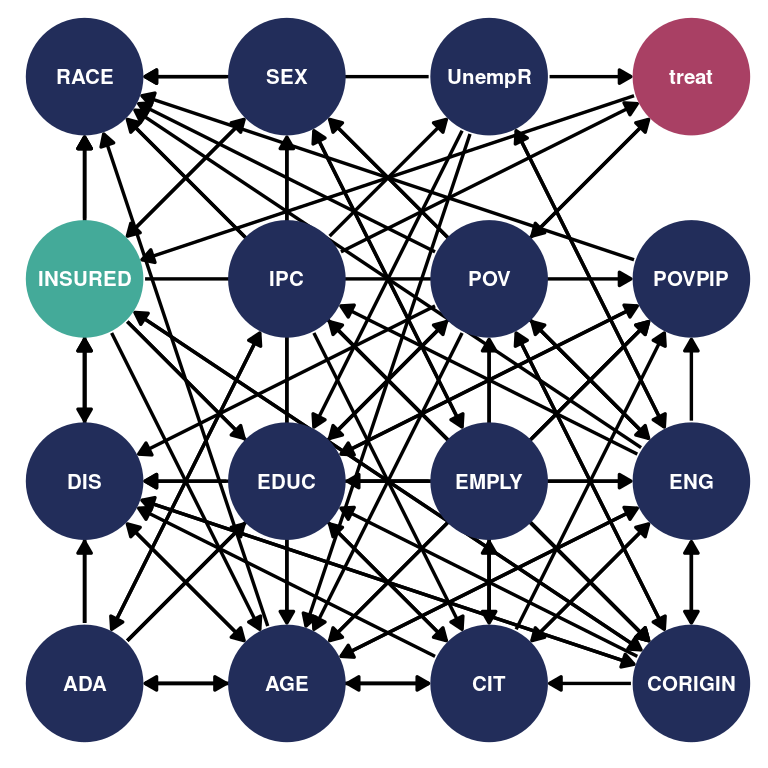

### Revised casual graph

To enhance the accuracy of the causal relationships represented in the DAG, I carefully reviewed and manually edited the graph by removing paths that contradicted my domain knowledge or appeared implausible within the context. By applying these revisions, the resulting DAG, illustrated in graph 2, aligns more closely with my expertise in the field and provides a more trustworthy representation of the underlying causal structure in my analysis.

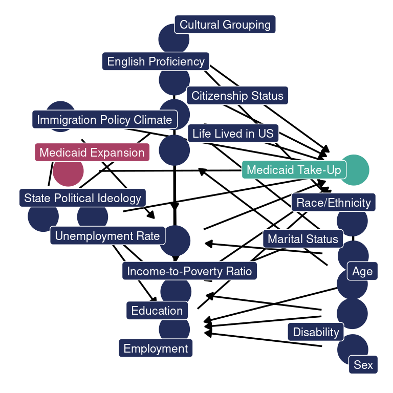

### Minimal adjustment set

The identified causal relationship between Medicaid expansion and Medicaid take-up in the revised DAG provides compelling evidence that changes in the treatment variable directly influence changes in the outcome variable. This finding suggests that interventions targeting the treatment variable, such as expanding Medicaid coverage, can potentially have a substantial impact on improving the rate of Medicaid take-up.

by conducting backdoor analysis I identified the necessary adjustment set, revealing that variables Citizenship Status, Immigration Policy Climate, Unemployment Rate need to be controlled for to accurately estimate the causal effect between Medicaid expansion and Medicaid take-up.

```r
adjustmentSets(findag)
```

```
## { Citizenship Status, Immigration Policy Climate, Unemployment Rate }
## { State Political Ideology, Unemployment Rate }
```

### Simplified causal graph

To enhance the clarity and interpretability of the graph, I employed a strategy to simplify its complexity. This involved grouping related variables into single nodes, such as combining ‘education,’ ‘income,’ and ‘employment’ into a unified node labeled ‘Socioeconomic.’ The streamlined representation of the underlying relationships can be observed in Graph 3.

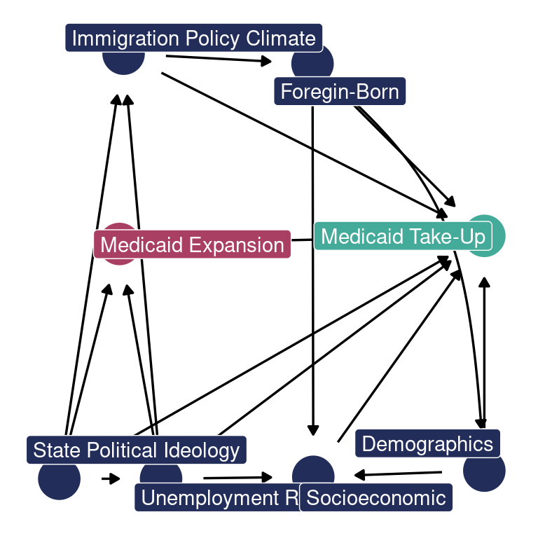

Although utilizing causal discovery algorithms has limitations, such as assuming the adequacy of observed variables and relying on the absence of unobserved confounders, efforts were made to include relevant variables in the analysis. However, it is possible that unmeasured confounders may exist, potentially introducing biases into the identified causal relationships. Therefore, the obtained graph may not precisely represent the true underlying causal structure..

Due to these limitations, I do not solely rely on this graph and its suggested adjustment set for estimating causal effects in my analysis. Nonetheless, the DAG derived from the causal discovery approach serves as a valuable tool for generating hypotheses and guiding the modeling process, as well as informing the selection of control variables in my DID approach analysis.

## Event Study and Parallel Trend Assumption

## Difference-in-Differences Model Results